# CommonDataCleansing

```python
import pandas as pd
import glob
from azure.storage.blob.blockblobservice import BlockBlobService
import matplotlib.pyplot as plt
import numpy as np

pd.__version__
```

```
'1.4.2'
```

## Data download

Die gesammelten Daten befinden sich in der Azure Cloud, im Azure Storage Blob Format. Dabei enhält jede Datei einen 10 sekündigen Ausschnitt der Daten im CSV Format.

In Folge werden die einzelnen Dateien heruntergeladen und in eine temporäre CSV Datei test.csv geschrieben.

```python
block_blob_service = BlockBlobService(account_name='activityprofiles', account_key='vx5JFWqh2ajuF6iQey3xj0o3BJ0o2EZaPxtS1ME28a/9y1+e06SYXnYWoMqhh4OaY5ZRf4wKmZXgJf3im0Bmuw==')

generator = block_blob_service.list_blobs('app')

fp = open('test.csv', 'bw')

for blob in generator:
    # Using `get_blob_to_bytes`
    b = block_blob_service.get_blob_to_bytes('app', blob.name)
    fp.write(b.content)
    # Or using `get_blob_to_stream`
    # service.get_blob_to_stream(container_name, blob.name, fp)

fp.flush()
fp.close()
```

[output not shown]

[output cut: 7 more lines]

## Data cleaning

```python
lengths = []
file = open("test.csv")
lines = file.readlines()
file.close()

for line in lines:
    elements = line.split(",")
    lengths.append(len(elements))

pd.Series(lengths).value_counts()
```

```
18    1717300
33     115428
32        140
dtype: int64
```

Nach dem Einlesen der temporären CSV-Datei, muss ein erstes Problem behandelt werden. Es existieren CSV Zeilen, welche die Dezimalstellen der Sensorwerte mit ',' anstatt '.' trennten. Da wir dieses Zeichen ebenfalls zur Trennung der CSV Einträge nutzten, existieren nun Zeilen mit 33 Elemente anstatt 18. Das Problem könnte durch Spracheinstellungen oder Einstellungen des Smartphone Herstellers verursacht worden sein. Da nur wenige Werte mit 32 Elementen existieren, werden diese ignoriert.

Das Problem wurde bei Daten des Android Gerätes von Flavio festgestellt. Um es zu beheben, werden die betroffenen Kommas in folgendem Code durch Punkte ersetzt.

```python
# convert 32 to 18 length
def bad_line_handler(bad_line):
    elements = bad_line[:3]
    for i in range(0, len(bad_line[3:]), 2):
        elements.append(f"{bad_line[i+3]}.{bad_line[i+4]}")
    return elements

lines_ignored = 0
lines_new = []

# convert 33 elements to 18, drop 32
for i, line in enumerate(lines):
    elements = lines[i].split(",")
    if(len(elements) == 18):
        lines_new.append(line)
    elif(len(elements) == 33):
        correct_line = bad_line_handler(elements)
        lines_new.append(str.join(",", correct_line))
    elif(len(elements) == 32):
        # other invalid format, ignore line
        lines_ignored += 1
        pass
    else:
        raise (f"ERROR: unknown error at line {i}")

print(f"{lines_ignored} Zeilen wurden ignoriert.")
print(f"{len(lines_new)} Zeilen sind nun verfügbar.")
```

```
140 Zeilen wurden ignoriert.
1832728 Zeilen sind nun verfügbar.
```

Die reparierten CSV Daten werden nun wieder in die temporäre CSV Datei geschrieben, deren Inhalt wird ersetzt.

```python
file = open("test.csv", "w")
file.writelines(lines_new)
file.close()

del lines
del lines_new
```

Die reparierte CSV Datei wird nun wieder eingelesen, diesmal als Pandas DataFrame. Weiter wird der Header der Daten hinzugefügt.

```python
df = pd.read_csv('test.csv', index_col=False, header=None) #engine="python", on_bad_lines=bad_line_handler
df.columns = ['time','name','activity','acc_x','acc_y','acc_z','mag_x','mag_y','mag_z','gyr_x','gyr_y','gyr_z','ori_x','ori_y','ori_z','ori_w','lat','long']

print(df.shape)
```

```
(1832728, 18)
```

```python
 # drop test entry
 df_clean = df.loc[df['time'] != 'Test04.03.2022 07:48:54.917', :]
```

Ein Eintrag musste entfernt werden, welcher ganz zu Beginn den Weg in die Datenbasis gefunden hat. Damit kann time in ein DateTime Objekt konvertiert werden. Dies nimmt bei dieser Anzahl Datenpunkten einige Zeit in Anspruch.

```python
# convert datetime format, yess this takes 5 min. :/
df_clean.loc[:, 'time'] = pd.to_datetime(df_clean.loc[:, 'time'] + "000") # format="%d.%m.%Y %H:%M.%S.%f"
```

Als Nächstes werden alle Daten von dem 03.03.2022 gelöscht. Vor diesem Datum hatte die App einen Bug, welcher die Sensordaten verfälschte.

```python
# drop all data before 3.3.2022, because of incorrect data loading
df_clean = df_clean[df_clean['time'] > pd.to_datetime('03.03.2022 08:00:00')]
```

```python
np.array(df_clean['name'].unique())
```

```
array(['Raphi', 'pascal', 'Flavio',
       'Ra es dd des d des d de d de y dephi',
       'Ra es dd des d des d de d de y de yphi',
       'Ra es dd des d des d de d dephi',
       'Ra es dd des d des d de d de yphi', 'Ra es dd des dphi',
       'Ra es dd des d desphi', 'Ra es dd des d des dphi',
       'Ra es dd des d des d dephi', 'Ra es dd des d des d de dphi',
       'Ra esphi', 'Ra es dphi', 'Ra es ddphi', 'Ra es dd desphi',
       'Ra es dd des d des d de d de y de y##*###2phi$#$#',
       'Ra es dd des d des d de d de y de y##*###2phi$#',
       'Ra es dd des d des d de d de y de y##*###2phi$#$',
       'Ra es dd des d des d de d de y de y##*###2phi$',
       'Ra es dd des d des d de d de y de y#phi',
       'Ra es dd des d des d de d de y de y##phi',
       'Ra es dd des d des d de d de y de y##*phi',
       'Ra es dd des d des d de d de y de y##*#phi',
       'Ra es dd des d des d de d de y de y##*##phi',
       'Ra es dd des d des d de d de y de y##*###phi',
       'Ra es dd des d des d de d de y de y##*###2phi',
       'Ra es dd des d des d de d de y de y##*###2ph',
       'Ra es dd des d des d de d de y de y##*###2p',
       'Ra es dd des d des d de d de y de y##*###',
       'Ra es dd des d des d de d de y de y##*##',
       'Ra es dd des d des d de d de y de y##*',
       'Ra es dd des d des d de d de y de y#',
       'Ra es dd des d des d de d de y de y',
       'Ra es dd des d des d de d de y de ',
       'Ra es dd des d des d de d de y de',
       'Ra es dd des d des d de d de y d',
       'Ra es dd des d des d de d de y ',
       'Ra es dd des d des d de d de y', 'Ra es dd des d des d de d de ',
       'Ra es dd des d des d de d de', 'Ra es dd des d des d de d d',
       'Ra es dd des d des d de d ', 'Ra es dd des d des d de d',
       'Ra es dd des d des d de ', 'Ra es dd des d des d de',
       'Ra es dd des d des d d', 'Ra es dd des d des d',
       'Ra es dd des d des ', 'Ra es dd des d des', 'Ra es dd des d d',
       'Ra es dd des d ', 'Ra es dd des d', 'Ra es dd des ',
       'Ra es dd des', 'Ra es dd d', 'Ra es dd ', 'Ra es dd', 'Ra es d',
       'Ra es ', 'Ra e', 'Ra ', 'Ra', 'R', nan, 'Rap', 'Raph', 'Raphu',
       'Ronny', 'Simon', 'test'], dtype=object)
```

```python
df_clean['name'].value_counts()[0:10]
```

```
pascal                                               475906
Flavio                                               443469
Raphi                                                357169
Ronny                                                281665
Simon                                                267060
Ra es dd des d des d de d de y de y##*###2phi$#$#       744
Ra es dd des d des d de d de y de y##*###2phi$          241
test                                                    238
Ra es dd des d des d de d de y de y##*###2phi$#         227
Ra es dd des d des d de d de y de y##*###2phi           193
Name: name, dtype: int64
```

Die Eigenschaft "name" wird in der App als Freitext gesetzt. Wie man hier sehen kann, sind dabei sehr spezielle Namen eingetragen worden. Da diese Werte nur sehr selten vorgekommen sind, werden diese im Anschluss entfernt.

```python
# drop invalid user
df_clean = df_clean[(df_clean['name'].isin(['Raphi', 'pascal', 'Flavio', 'Ronny', 'Simon']))]
```

Das neue Dataframe wird nun gespeichert.

```python
df_clean.to_csv("df_clean.csv")

del df
```

## Data visualization

```python
df_clean = pd.read_csv("df_clean.csv")
df_clean.shape
```

```
(1825269, 19)
```

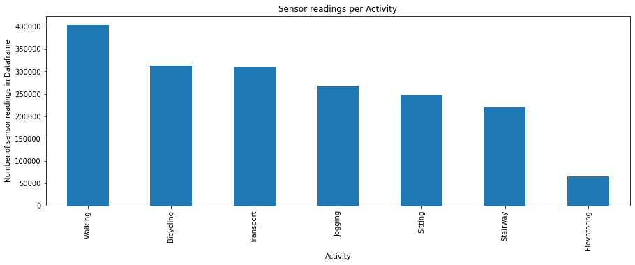

```python
df_clean['activity'].value_counts().plot(kind='bar', title='Sensor readings per Activity', xlabel='Activity', ylabel='Number of sensor readings in Dataframe', figsize=(15, 5))
plt.show()
```

In dieser Darstellung ist dargstellt, wie häufig die einzelnen Aktivitäten im Datensatz vorkommen. In Folge sind die Anzahl Einträge noch in numerischer Form dargestellt.

```python
df_clean['activity'].value_counts()
```

```
Walking        403506
Bicycling      312543
Transport      309516
Jogging        267867
Sitting        247533
Stairway       219563
Elevatoring     64741
Name: activity, dtype: int64
```

```
[]
```

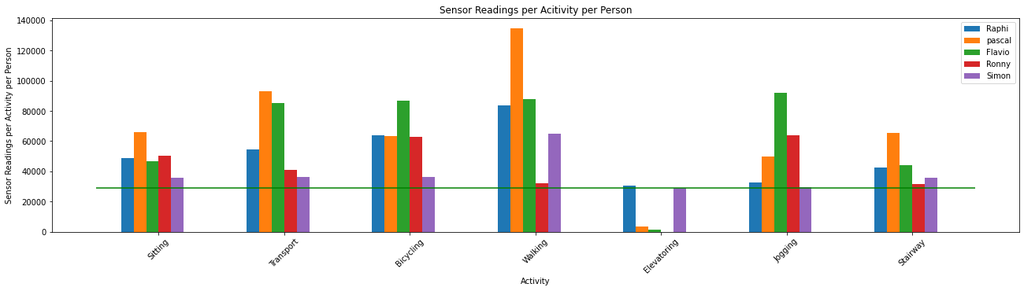

```python
n = np.arange(len(df_clean['activity'].unique()))

fig, ax = plt.subplots(figsize=(22, 5))
names = []
for i, name in enumerate(df_clean['name'].unique()):
    ax.bar(n + (i/len(df_clean['name'].unique())/2 - 0.25), df_clean.loc[df_clean['name'] == name, 'activity'].value_counts().reindex(df_clean['activity'].unique(), fill_value=0), width=0.1)
    names.append(name)

# minline: 2h/5=24min, 1440s per person, 20meas/sec -> 28'800 measurements
plt.xticks(n, list(df_clean['activity'].unique()), rotation=45)
plt.legend(names)
ax.hlines(y=28800, xmin=-0.5, xmax=6.5, colors='green')
ax.set_title("Sensor Readings per Acitivity per Person")
ax.set_xlabel("Activity")
ax.set_ylabel("Sensor Readings per Activity per Person")
#plt.legend(a[1].unique())
plt.plot()
```

Die Anforderung konnte in der Aktivität "Elevatoring" von drei Personen nicht erfüllt werden. Im Lift war häufig das Senden der Daten nicht möglich, da keine Internetverbindung bestand. Da das autmatische Resending der App nicht wirklich funktionierte, wurden die Daten häufig nicht gepseichert. Wir waren uns dieser Einschränkung bewusst und definierten mit den vorhandenen Daten weiterzuarbeiten.

### Datenexploration

In diesen Darstellungen werden die gemessenen Koordinaten des GPS Signals visualisiert.

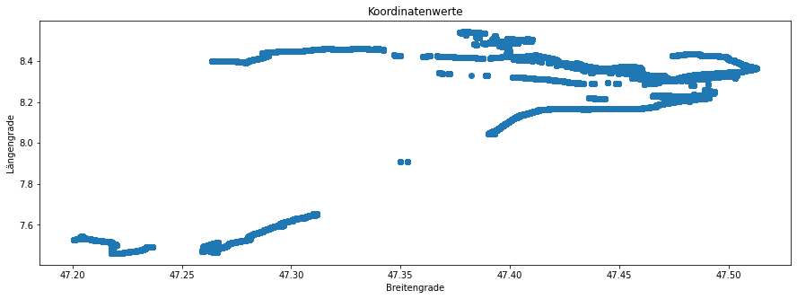

```python
# coordinates visualization
fig, ax = plt.subplots(figsize=(15, 5))
ax.scatter(df_clean['lat'].values, df_clean['long'].values)
ax.set_title("Koordinatenwerte")
ax.set_xlabel("Breitengrade")
ax.set_ylabel("Längengrade")
plt.show()
```

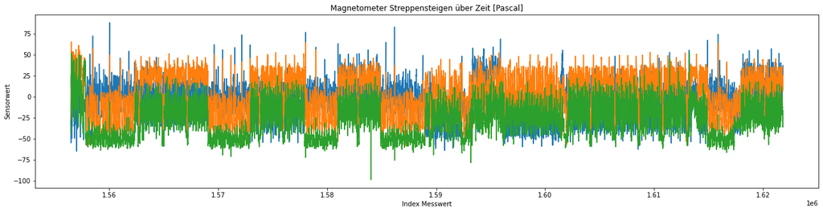

```python
fig, ax = plt.subplots(figsize=(22, 5))
ax.plot(df_clean.loc[(df_clean['name'] == 'pascal') & (df_clean['activity'] == 'Stairway'), ['mag_x', 'mag_y', 'mag_z']])
ax.set_title("Magnetometer Streppensteigen über Zeit [Pascal]")
ax.set_ylabel("Sensorwert")
ax.set_xlabel("Index Messwert")
plt.show()
```

In dieser Darstellung sind Daten vom Treppensteigen des Magnetometers über die Zeit visualisiert.

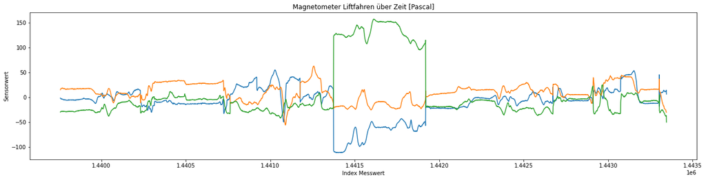

```python
fig, ax = plt.subplots(figsize=(22, 5))
ax.plot(df_clean.loc[(df_clean['name'] == 'pascal') & (df_clean['activity'] == 'Elevatoring'), ['mag_x', 'mag_y', 'mag_z']])
ax.set_title("Magnetometer Liftfahren über Zeit [Pascal]")
ax.set_ylabel("Sensorwert")
ax.set_xlabel("Index Messwert")
plt.show()
```

In dieser Darstellung sind Daten des Magnetometers vom Liftfahren visualisiert. Bemerkenswert ist der Unterschied der Bewegungsprofile.